# FINAL PROJECT INTRO TO DATA SCIENCE 2023

By: Ofir Salomon and Itzik Ben Harush

```python
import asyncio
from aiohttp import ClientSession
import itertools
from parsel import Selector
import json
import re
import csv
import scipy.stats as stats
import pandas as pd
import numpy as np
import matplotlib.pyplot as plt
import seaborn as sns
from scipy.stats import t

from sklearn.model_selection import train_test_split
from sklearn.linear_model import LogisticRegression
from sklearn.metrics import accuracy_score, precision_score, recall_score, f1_score

import requests
from bs4 import BeautifulSoup
from urllib.parse import urlencode
from httpx import AsyncClient
import nest_asyncio
from urllib.parse import urlencode
from typing import List
nest_asyncio.apply()
```

# SCRAPING:

In this section we scrape data from a website named: Booking. This is the most popular site for reviews and grades of hotels from all over the world. It has done so for many years so we decided to use it. We took most hotels from this website and created a Data Frame. Not all the data is presented in the first page so we had to use crawling and open the inner page to reach more data.

```python
HEADERS = {
    "User-Agent": "Mozilla/5.0 (Windows NT 10.0; Win64; x64) AppleWebKit/537.36 (KHTML, like Gecko) Chrome/62.0.3202.94 Safari/537.36",
    "Accept-Encoding": "gzip, deflate, br",
    "Accept": "text/html,application/xhtml+xml,application/xml;q=0.9,image/webp,image/apng,*/*;q=0.8",
    "Connection": "keep-alive",
    "Accept-Language": "en-US,en;q=0.9,lt;q=0.8,et;q=0.7,de;q=0.6",
}

async def search_page(
    query,
    session: ClientSession,
    checkin: str = "",
    checkout: str = "",
    number_of_rooms=1,
    offset: int = 0,
    proxy: str = None,
):
    """Scrapes a single hotel search page of booking.com"""
    checkin_year, checking_month, checking_day = checkin.split("-") if checkin else "", "", ""
    checkout_year, checkout_month, checkout_day = checkout.split("-") if checkout else "", "", ""

    url = "https://www.booking.com/searchresults.html"
    url += "?" + urlencode(
        {
            "ss": query,
            "checkin_year": checkin_year,
            "checkin_month": checking_month,
            "checkin_monthday": checking_day,
            "checkout_year": checkout_year,
            "checkout_month": checkout_month,
            "checkout_monthday": checkout_day,
            "no_rooms": number_of_rooms,
            "offset": offset,
        }
    )

    # Use proxy if provided
    if proxy:
        async with session.get(url, proxy=proxy) as response:
            return await response.text()
    else:
        async with session.get(url) as response:
            return await response.text()


def parse_hotel_preview(html: str):
    """Parses hotel preview data from search page HTML"""
    sel = Selector(text=html)

    hotel_previews = {}
    for hotel_box in sel.xpath('//div[@data-testid="property-card"]'):
        url = hotel_box.xpath('.//h3/a[@data-testid="title-link"]/@href').get("").split("?")[0]
        hotel_previews[url] = url

    return hotel_previews


def parse_search_total_results(html: str):
    """Parses the total number of search results"""
    return 6000  # Example value, replace with actual parsing logic


async def scrape_search(
    query,
    session: ClientSession,
    checkin: str = "",
    checkout: str = "",
    number_of_rooms=1,
    offset: int = 0,
    proxies: List[str] = None,
    max_results: int = 6000,
):
    """Scrapes hotel previews from a given search query"""
    first_page = await search_page(
        query=query, session=session, checkin=checkin, checkout=checkout, number_of_rooms=number_of_rooms, offset=offset
    )
    total_results = parse_search_total_results(first_page)

    tasks = []
    if proxies:
        for curr_offset, proxy in zip(range(offset, total_results, 25), cycle(proxies)):
            tasks.append(
                search_page(
                    query=query,
                    session=session,
                    checkin=checkin,
                    checkout=checkout,
                    number_of_rooms=number_of_rooms,
                    offset=curr_offset,
                    proxy=proxy,
                )
            )
    else:
        tasks = [
            search_page(
                query=query,
                session=session,
                checkin=checkin,
                checkout=checkout,
                number_of_rooms=number_of_rooms,
                offset=curr_offset,
            )
            for curr_offset in range(offset, total_results, 25)
        ]

    hotel_previews = {}
    for response, curr_offset in zip(await asyncio.gather(*tasks), range(offset, total_results, 25)):
        hotel_previews.update(parse_hotel_preview(response))
        if len(hotel_previews) >= max_results:
            break

    return hotel_previews


async def run():
    # Read the list of proxies from the TXT file
    with open('Proxy.txt', 'r') as file:
        proxies = [line.strip() for line in file if line.strip()]

    async with ClientSession(headers=HEADERS) as session:
        complete_data = pd.DataFrame()  # Initialize an empty DataFrame for complete data
        offset = 0  # Initial offset
        hotel_previews = {}  # Initialize hotel_previews dictionary

        # Read the list of states from the 'States.txt' file
        with open('States.txt', 'r') as file:
            states = [line.strip() for line in file if line.strip()]

        for state in states:
            while len(hotel_previews) < 6000:
                # Select a proxy for the current iteration
                proxy = next(cycle(proxies))

                # Calculate the remaining number of results needed
                remaining_results = 6000 - len(hotel_previews)

                # Limit the max_results to the remaining results needed
                max_results = min(remaining_results, 25)

                # Scrape the search results using the current state as the query
                country_results = await scrape_search(
                    query=state,
                    session=session,
                    proxies=[proxy],
                    offset=offset,
                    max_results=max_results,
                )

                # If no results are obtained, break the loop
                if not country_results:
                    break

                # Update the hotel_previews dictionary with the current iteration's results
                hotel_previews.update(country_results)

                # Export the results to the results.csv file for the current iteration
                df = pd.DataFrame.from_dict(country_results, orient="index", columns=["url"])
                df.to_csv('results.csv', mode='a', header=False, index=False)

                # Update the offset for the next iteration
                offset += 25

                if len(hotel_previews) >= 6000:
                    print("Desired number of results reached. Stopping the loop.")
                    break

                # Update the complete_data DataFrame with the current iteration's results
                complete_data = pd.concat([complete_data, df])

        # Export the complete_data DataFrame to a separate CSV file
        complete_data.to_csv('complete_results.csv', index=False)

asyncio.run(run())
```

```python
Hotels = []

# Read URLs from results.csv
with open('results.csv', 'r') as csv_file:
    csv_reader = csv.reader(csv_file)
    next(csv_reader)  # Skip header row

    # Read proxy list from proxy.txt
    with open('Proxy.txt', 'r') as proxy_file:
        proxy_list = proxy_file.read().splitlines()

    proxy_cycle = itertools.cycle(proxy_list)  # Create a cycle iterator

    for row in csv_reader:
        url = row[0]  # Assuming URL is in the first column of the CSV

        # Select a proxy from the cycle for the current request
        proxy = next(proxy_cycle)
        proxy_dict = {'http': proxy, 'https': proxy}

        try:
            resp = requests.get(url, proxies=proxy_dict)
            soup = BeautifulSoup(resp.text, 'html.parser')

            hotel = {}
            hotel["name"] = soup.find("h2", {"class": "pp-header__title"}).text
            hotel["rating"] = soup.find("div", {"class": "d10a6220b4"}).text

            # Extracting the text from the line containing "atnm"
            atnm_line = soup.find(text=lambda t: t and "atnm" in t.lower())
            if atnm_line:
                # Use regular expressions to extract the value of "atnm"
                match = re.search(r"atnm: '(.*?)'", atnm_line)
                if match:
                    hotel["atnm"] = match.group(1)
                else:
                    hotel["atnm"] = ""
            else:
                hotel["atnm"] = ""

            # Extracting the text from the line containing "region_name"
            region_name_line = soup.find(text=lambda t: t and "region_name" in t.lower())
            if region_name_line:
                # Use regular expressions to extract the value of "region_name"
                match = re.search(r"region_name: '(.*?)'", region_name_line)
                if match:
                    hotel["region_name"] = match.group(1)
                else:
                    hotel["region_name"] = ""
            else:
                hotel["region_name"] = ""


            amenities = [
                "Outdoor swimming pool",
                "Restaurant",
                "Excellent Breakfast",
                "Free parking",
                "Free WiFi",
                "Fitness center",
                "Breakfast",
                "Bar",
                "Very Good Breakfast",
                "Indoor swimming pool",
                "Spa",
                "3 swimming pools",
                "2 swimming pools",
                "4 swimming pools",
                "Room service",
                "Beachfront",
                "Private beach area",
                "WiFi in all areas"
            ]

            for amenity in amenities:
                amenity_text = soup.find(text=amenity)
                hotel[amenity.lower().replace(" ", "_")] = 1 if amenity_text else 0

            Hotels.append(hotel)
        except Exception as e:
            print(f"Error occurred for URL: {url}")
            print(e)

# Save data to bigdata.csv
fieldnames = Hotels[0].keys() if Hotels else []
with open('bigdata.csv', 'w', newline='') as csv_file:
    writer = csv.DictWriter(csv_file, fieldnames=fieldnames)
    writer.writeheader()
    writer.writerows(Hotels)
```

```python
df = pd.read_csv('bigdata.csv')
df
```

|  | name | rating | atnm | region_name | outdoor_swimming_pool | restaurant | excellent_breakfast | free_parking | free_wifi | fitness_center | ... | very_good_breakfast | indoor_swimming_pool | spa | 3_swimming_pools | 2_swimming_pools | 4_swimming_pools | room_service | beachfront | private_beach_area | wifi_in_all_areas |
| --- | --- | --- | --- | --- | --- | --- | --- | --- | --- | --- | --- | --- | --- | --- | --- | --- | --- | --- | --- | --- | --- |
| 0 | Desert Inn | 7.6 | Motels | New Mexico | 0 | 0 | 0 | 0 | 1 | 1 | ... | 0 | 1 | 1 | 0 | 0 | 0 | 0 | 0 | 0 | 0 |
| 1 | Super 8 by Wyndham Portales | 6.9 | Motels | New Mexico | 0 | 0 | 0 | 1 | 1 | 0 | ... | 0 | 0 | 0 | 0 | 0 | 0 | 0 | 0 | 0 | 0 |
| 2 | Ohkay Hotel Casino | 7.9 | Hotels | New Mexico | 1 | 1 | 0 | 1 | 1 | 1 | ... | 0 | 0 | 1 | 0 | 0 | 0 | 0 | 0 | 0 | 0 |
| 3 | Best Western Plus Portales Inn | 8.6 | Hotels | New Mexico | 0 | 0 | 0 | 1 | 1 | 1 | ... | 0 | 0 | 1 | 0 | 0 | 0 | 0 | 0 | 0 | 0 |
| 4 | Holiday Inn Express & Suites Portales, an IHG ... | 8.3 | Hotels | New Mexico | 0 | 0 | 0 | 0 | 1 | 1 | ... | 0 | 0 | 1 | 0 | 0 | 0 | 0 | 0 | 0 | 0 |
| ... | ... | ... | ... | ... | ... | ... | ... | ... | ... | ... | ... | ... | ... | ... | ... | ... | ... | ... | ... | ... | ... |
| 5928 | Motel 6-Porterville, CA | 6.3 | Hotels | California | 1 | 0 | 0 | 1 | 1 | 0 | ... | 0 | 0 | 0 | 0 | 0 | 0 | 0 | 0 | 0 | 0 |
| 5929 | Wildflower Boutique Motel | 9.4 | Hotels | California | 0 | 0 | 0 | 1 | 1 | 0 | ... | 0 | 0 | 0 | 0 | 0 | 0 | 0 | 0 | 0 | 0 |
| 5930 | WorldMark Clear Lake | 9.1 | Hotels | California | 0 | 0 | 0 | 1 | 0 | 0 | ... | 0 | 0 | 0 | 0 | 0 | 0 | 0 | 0 | 0 | 1 |
| 5931 | Sonesta Select Pleasant Hill | 8.0 | Hotels | California | 0 | 1 | 0 | 0 | 1 | 1 | ... | 0 | 0 | 1 | 0 | 0 | 0 | 0 | 0 | 0 | 0 |
| 5932 | Vineyard Country Inn | 8.8 | Inns | California | 1 | 0 | 0 | 1 | 1 | 0 | ... | 0 | 0 | 1 | 0 | 0 | 0 | 0 | 0 | 0 | 0 |

5933 rows × 22 columns

# PROCESSING

After receiving the required standings, We will examine the quantities of each type and then categorize the necessary records into binary and categorical.

```python
df.head()
df.info()
df.describe()
```

```
<class 'pandas.core.frame.DataFrame'>
RangeIndex: 5933 entries, 0 to 5932
Data columns (total 22 columns):
 #   Column                 Non-Null Count  Dtype
---  ------                 --------------  -----
 0   name                   5933 non-null   object
 1   rating                 5933 non-null   float64
 2   atnm                   5924 non-null   object
 3   region_name            5933 non-null   object
 4   outdoor_swimming_pool  5933 non-null   int64
 5   restaurant             5933 non-null   int64
 6   excellent_breakfast    5933 non-null   int64
 7   free_parking           5933 non-null   int64
 8   free_wifi              5933 non-null   int64
 9   fitness_center         5933 non-null   int64
 10  breakfast              5933 non-null   int64
 11  bar                    5933 non-null   int64
 12  very_good_breakfast    5933 non-null   int64
 13  indoor_swimming_pool   5933 non-null   int64
 14  spa                    5933 non-null   int64
 15  3_swimming_pools       5933 non-null   int64
 16  2_swimming_pools       5933 non-null   int64
 17  4_swimming_pools       5933 non-null   int64
 18  room_service           5933 non-null   int64
 19  beachfront             5933 non-null   int64
 20  private_beach_area     5933 non-null   int64
 21  wifi_in_all_areas      5933 non-null   int64
dtypes: float64(1), int64(18), object(3)
memory usage: 1019.9+ KB
```

|  | rating | outdoor_swimming_pool | restaurant | excellent_breakfast | free_parking | free_wifi | fitness_center | breakfast | bar | very_good_breakfast | indoor_swimming_pool | spa | 3_swimming_pools | 2_swimming_pools | 4_swimming_pools | room_service | beachfront | private_beach_area | wifi_in_all_areas |
| --- | --- | --- | --- | --- | --- | --- | --- | --- | --- | --- | --- | --- | --- | --- | --- | --- | --- | --- | --- |
| count | 5933.000000 | 5933.000000 | 5933.000000 | 5933.000000 | 5933.000000 | 5933.000000 | 5933.000000 | 5933.000000 | 5933.000000 | 5933.000000 | 5933.000000 | 5933.000000 | 5933.000000 | 5933.000000 | 5933.000000 | 5933.000000 | 5933.000000 | 5933.000000 | 5933.000000 |
| mean | 8.064858 | 0.280297 | 0.183381 | 0.008427 | 0.669139 | 0.934266 | 0.432665 | 0.616214 | 0.189617 | 0.022586 | 0.128603 | 0.585033 | 0.002528 | 0.026968 | 0.001011 | 0.120007 | 0.037586 | 0.009944 | 0.012978 |
| std | 1.200709 | 0.449182 | 0.387011 | 0.091421 | 0.470563 | 0.247837 | 0.495487 | 0.486348 | 0.392031 | 0.148591 | 0.334788 | 0.492758 | 0.050222 | 0.162003 | 0.031787 | 0.324997 | 0.190210 | 0.099233 | 0.113190 |
| min | 1.000000 | 0.000000 | 0.000000 | 0.000000 | 0.000000 | 0.000000 | 0.000000 | 0.000000 | 0.000000 | 0.000000 | 0.000000 | 0.000000 | 0.000000 | 0.000000 | 0.000000 | 0.000000 | 0.000000 | 0.000000 | 0.000000 |
| 25% | 7.500000 | 0.000000 | 0.000000 | 0.000000 | 0.000000 | 1.000000 | 0.000000 | 0.000000 | 0.000000 | 0.000000 | 0.000000 | 0.000000 | 0.000000 | 0.000000 | 0.000000 | 0.000000 | 0.000000 | 0.000000 | 0.000000 |
| 50% | 8.200000 | 0.000000 | 0.000000 | 0.000000 | 1.000000 | 1.000000 | 0.000000 | 1.000000 | 0.000000 | 0.000000 | 0.000000 | 1.000000 | 0.000000 | 0.000000 | 0.000000 | 0.000000 | 0.000000 | 0.000000 | 0.000000 |
| 75% | 8.800000 | 1.000000 | 0.000000 | 0.000000 | 1.000000 | 1.000000 | 1.000000 | 1.000000 | 0.000000 | 0.000000 | 0.000000 | 1.000000 | 0.000000 | 0.000000 | 0.000000 | 0.000000 | 0.000000 | 0.000000 | 0.000000 |
| max | 10.000000 | 1.000000 | 1.000000 | 1.000000 | 1.000000 | 1.000000 | 1.000000 | 1.000000 | 1.000000 | 1.000000 | 1.000000 | 1.000000 | 1.000000 | 1.000000 | 1.000000 | 1.000000 | 1.000000 | 1.000000 | 1.000000 |

# Calculate normalized rating using cumulative distribution function (CDF)

```python
df.loc[:, 'rating'] = pd.to_numeric(df['rating'], errors='coerce')
mean_rating = df['rating'].mean()
std_rating = df['rating'].std()
df.loc[:, 'rating_normalized'] = stats.norm.cdf(df['rating'], mean_rating, std_rating)
print(df)
```

```
                                                   name  rating    atnm
0                                            Desert Inn     7.6  Motels  \
1                           Super 8 by Wyndham Portales     6.9  Motels
2                                    Ohkay Hotel Casino     7.9  Hotels
3                        Best Western Plus Portales Inn     8.6  Hotels
4     Holiday Inn Express & Suites Portales, an IHG ...     8.3  Hotels
...                                                 ...     ...     ...
5928                            Motel 6-Porterville, CA     6.3  Hotels
5929                          Wildflower Boutique Motel     9.4  Hotels
5930                               WorldMark Clear Lake     9.1  Hotels
5931                       Sonesta Select Pleasant Hill     8.0  Hotels
5932                               Vineyard Country Inn     8.8    Inns

     region_name  outdoor_swimming_pool  restaurant  excellent_breakfast
0     New Mexico                      0           0                    0  \
```

[output cut: 51 more lines]

# Here you can see the distribution of ratings

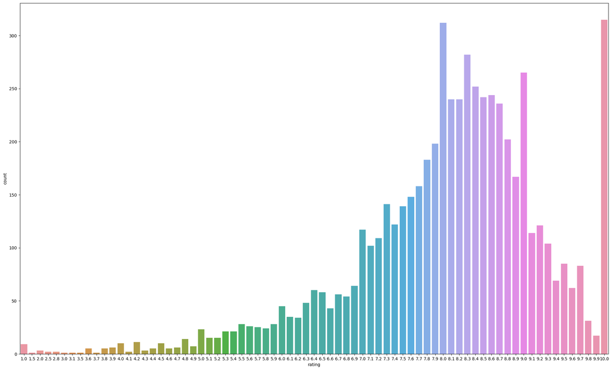

```python
plt.figure(figsize=(25, 15))  # Set the figure size (width, height)
sns.countplot(data=df, x='rating')
plt.show()
```

# Data Cleaning Section:

```python
df.isnull().sum()  # Check for missing values in each column
df = df.dropna()  # Remove rows with missing values
```

[figure not shown]

```python
import matplotlib.pyplot as plt

binary_cols = ['outdoor_swimming_pool', 'restaurant', 'excellent_breakfast', 'free_parking', 'free_wifi',
               'fitness_center', 'breakfast', 'bar', 'very_good_breakfast', 'indoor_swimming_pool',
               'spa', '3_swimming_pools', '2_swimming_pools', '4_swimming_pools', 'room_service',
               'beachfront', 'private_beach_area', 'wifi_in_all_areas']

fig, axes = plt.subplots(len(binary_cols), 1, figsize=(5, len(binary_cols) * 6))

for i, col in enumerate(binary_cols):
    ax = axes[i]
    value_counts = df[col].value_counts()
    ax.bar(value_counts.index, value_counts.values)
    ax.set_xlabel('Value')
    ax.set_ylabel('Count')
    ax.set_title(f"Counts of 1's and 0's in {col}")
    ax.set_xticks([0, 1])

plt.tight_layout()
plt.show()
```

# Deleting irrelevant columns.

```python
del df['excellent_breakfast']
del df['free_wifi']
del df['very_good_breakfast']
del df['3_swimming_pools']
del df['2_swimming_pools']
del df['4_swimming_pools']
del df['beachfront']
del df['private_beach_area']
del df['wifi_in_all_areas']
```

```python
df
```

|  | name | rating | atnm | region_name | outdoor_swimming_pool | restaurant | free_parking | fitness_center | breakfast | bar | indoor_swimming_pool | spa | room_service | rating_normalized |
| --- | --- | --- | --- | --- | --- | --- | --- | --- | --- | --- | --- | --- | --- | --- |
| 0 | Desert Inn | 7.6 | Motels | New Mexico | 0 | 0 | 0 | 1 | 1 | 0 | 1 | 1 | 0 | 0.349322 |
| 1 | Super 8 by Wyndham Portales | 6.9 | Motels | New Mexico | 0 | 0 | 1 | 0 | 1 | 0 | 0 | 0 | 0 | 0.165988 |
| 2 | Ohkay Hotel Casino | 7.9 | Hotels | New Mexico | 1 | 1 | 1 | 1 | 1 | 1 | 0 | 1 | 0 | 0.445397 |
| 3 | Best Western Plus Portales Inn | 8.6 | Hotels | New Mexico | 0 | 0 | 1 | 1 | 1 | 0 | 0 | 1 | 0 | 0.672089 |
| 4 | Holiday Inn Express & Suites Portales, an IHG ... | 8.3 | Hotels | New Mexico | 0 | 0 | 0 | 1 | 1 | 0 | 0 | 1 | 0 | 0.577631 |
| ... | ... | ... | ... | ... | ... | ... | ... | ... | ... | ... | ... | ... | ... | ... |
| 5928 | Motel 6-Porterville, CA | 6.3 | Hotels | California | 1 | 0 | 1 | 0 | 0 | 0 | 0 | 0 | 0 | 0.070802 |
| 5929 | Wildflower Boutique Motel | 9.4 | Hotels | California | 0 | 0 | 1 | 0 | 1 | 0 | 0 | 0 | 0 | 0.866923 |
| 5930 | WorldMark Clear Lake | 9.1 | Hotels | California | 0 | 0 | 1 | 0 | 0 | 0 | 0 | 0 | 0 | 0.805686 |
| 5931 | Sonesta Select Pleasant Hill | 8.0 | Hotels | California | 0 | 1 | 0 | 1 | 1 | 0 | 0 | 1 | 0 | 0.478461 |
| 5932 | Vineyard Country Inn | 8.8 | Inns | California | 1 | 0 | 1 | 0 | 1 | 0 | 0 | 1 | 0 | 0.729816 |

5924 rows × 14 columns

```python
# Assuming your DataFrame is named 'df'
hotel_counts = df['atnm'].value_counts()

print(hotel_counts)
```

```
atnm
Hotels                3462
Vacation Homes         802
Motels                 580
Apartments             364
Resorts                147
Inns                   137
Bed and Breakfasts     128
Lodges                 108
Condo Hotels            66
Guesthouses             33
Homestays               24
Hostels                 22
Villas                  14
Campgrounds             13
Luxury tents             9
Resort Villages          7
Country Houses           4
Farm Stays               3
Capsule Hotels           1
Name: count, dtype: int64
```

```python
# Assuming your DataFrame is named 'df'
types_to_delete = ['Capsule Hotels', 'Farm Stays', 'Country Houses', 'Resort Villages', 'Campgrounds', 'Luxury tents']
df = df[~df['atnm'].isin(types_to_delete)]

print(df)
```

```
                                                   name  rating    atnm
0                                            Desert Inn     7.6  Motels  \
1                           Super 8 by Wyndham Portales     6.9  Motels
2                                    Ohkay Hotel Casino     7.9  Hotels
3                        Best Western Plus Portales Inn     8.6  Hotels
4     Holiday Inn Express & Suites Portales, an IHG ...     8.3  Hotels
...                                                 ...     ...     ...
5928                            Motel 6-Porterville, CA     6.3  Hotels
5929                          Wildflower Boutique Motel     9.4  Hotels
5930                               WorldMark Clear Lake     9.1  Hotels
5931                       Sonesta Select Pleasant Hill     8.0  Hotels
5932                               Vineyard Country Inn     8.8    Inns

     region_name  outdoor_swimming_pool  restaurant  free_parking
0     New Mexico                      0           0             0  \
```

[output cut: 38 more lines]

# EDA & Visualization

Statistics such as mean, median, standard deviation, and quartiles to understand the central tendency and dispersion of the data.

# We will begin visualizing the data on a chromatic map

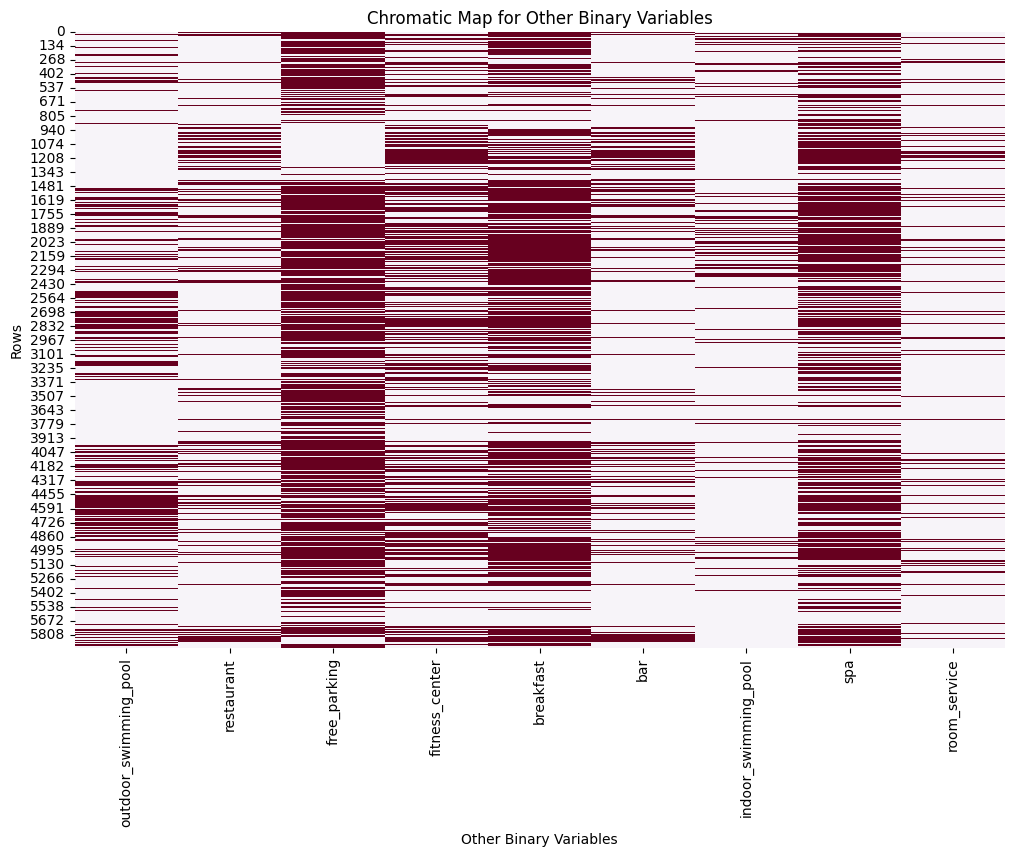

```python
other_binary_cols = ['outdoor_swimming_pool', 'restaurant', 'free_parking', 'fitness_center', 'breakfast',
               'bar', 'indoor_swimming_pool', 'spa', 'room_service']

# Create a subset DataFrame containing the other binary columns
other_binary_df = df[other_binary_cols]

# Generate the chromatic map for the other binary variables
plt.figure(figsize=(12, 8))
sns.heatmap(other_binary_df, cmap='PuRd', cbar=False)
plt.title('Chromatic Map for Other Binary Variables')
plt.xlabel('Other Binary Variables')
plt.ylabel('Rows')
plt.show()
```

# We continued with the representation of hotel types according to their rating

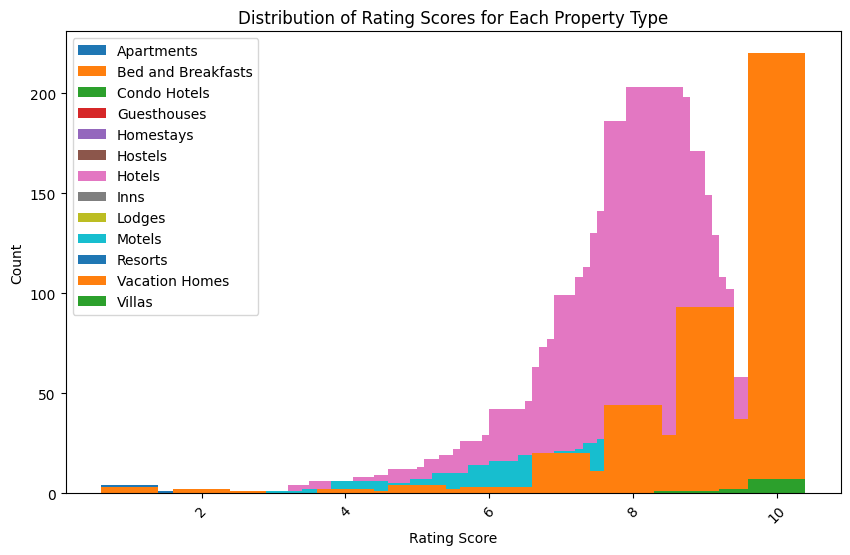

```python
grouped_ratings = df.groupby('atnm')['rating'].value_counts().unstack(fill_value=0)

# Get property types and rating scores
property_types = grouped_ratings.index
rating_scores = grouped_ratings.columns

# Create bar chart for each property type
fig, ax = plt.subplots(figsize=(10, 6))

for i, prop in enumerate(property_types):
    ratings = grouped_ratings.loc[prop]
    ax.bar(rating_scores, ratings, label=prop)

ax.set_xlabel('Rating Score')
ax.set_ylabel('Count')
ax.set_title('Distribution of Rating Scores for Each Property Type')
ax.legend()
plt.xticks(rotation=45)
plt.show()
```

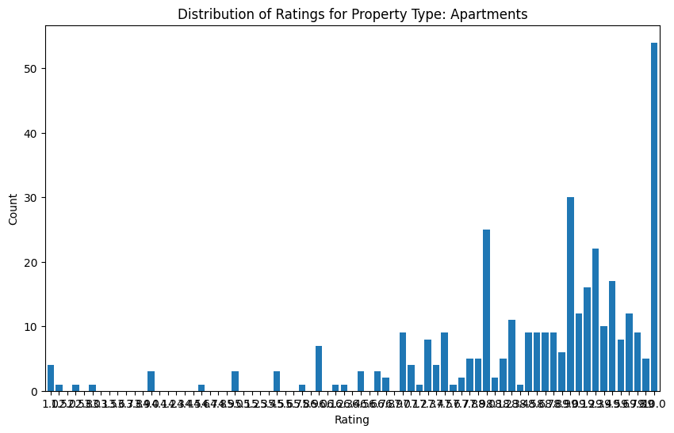

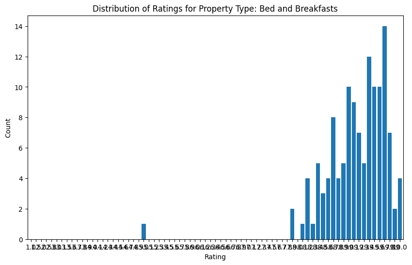

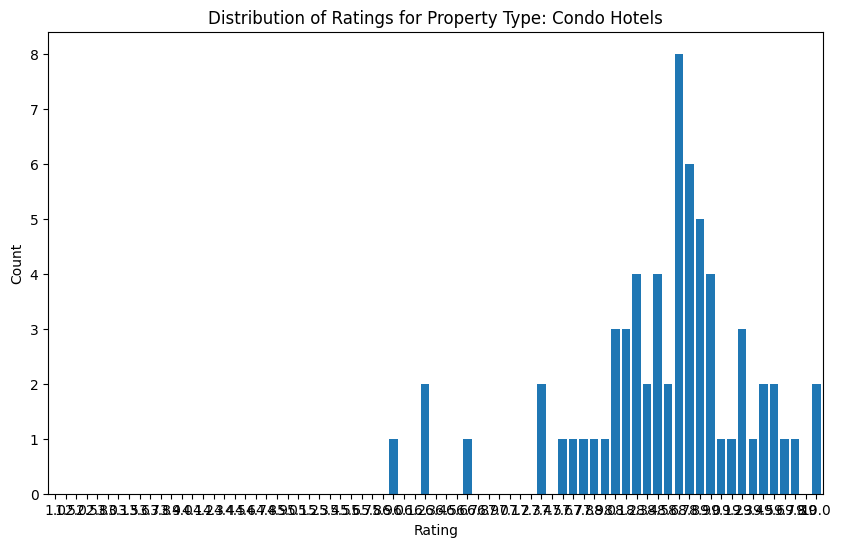

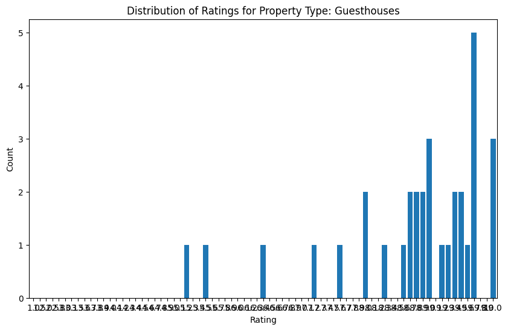

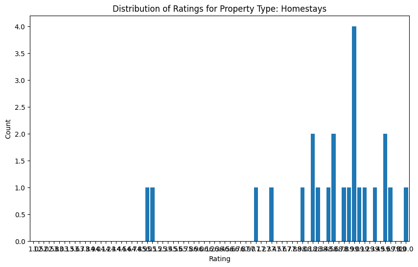

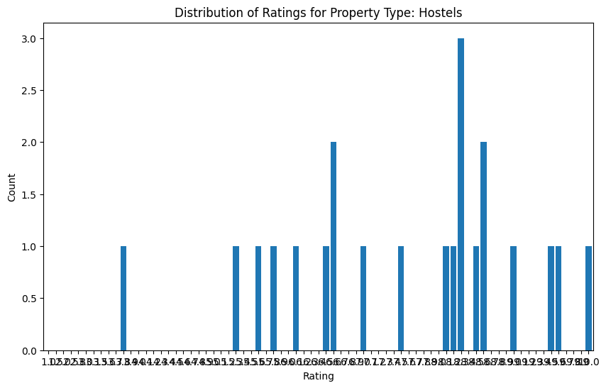

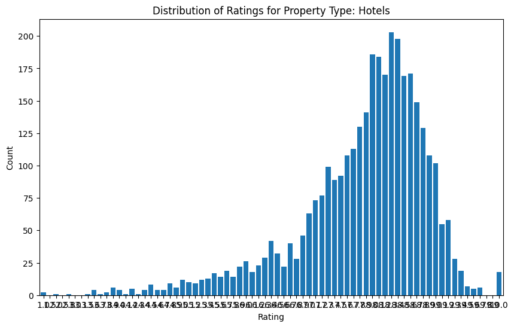

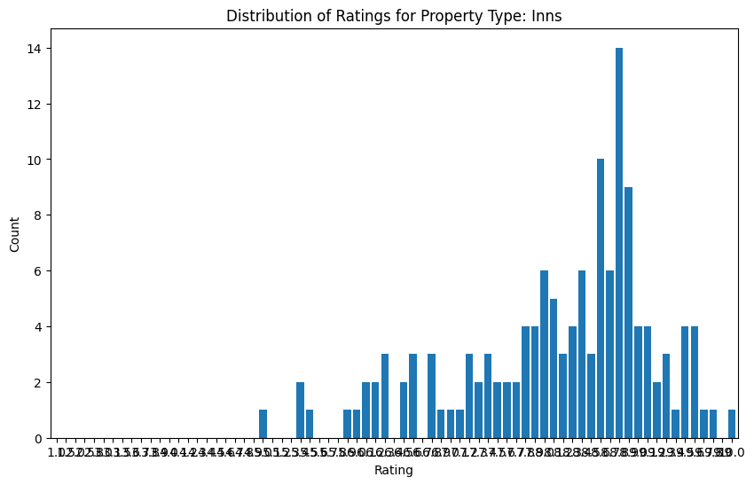

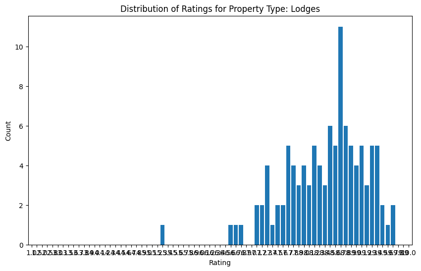

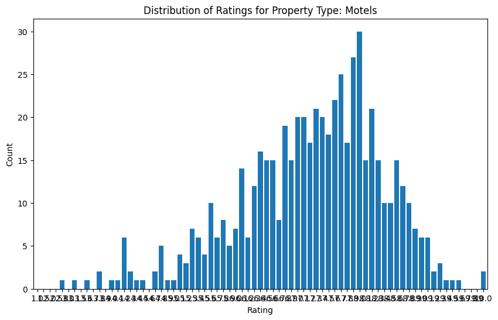

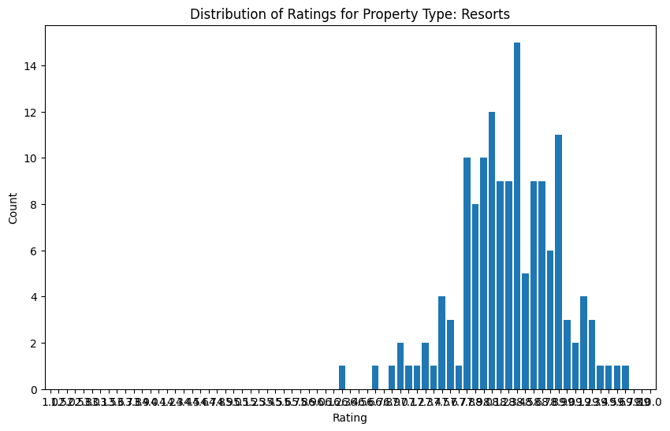

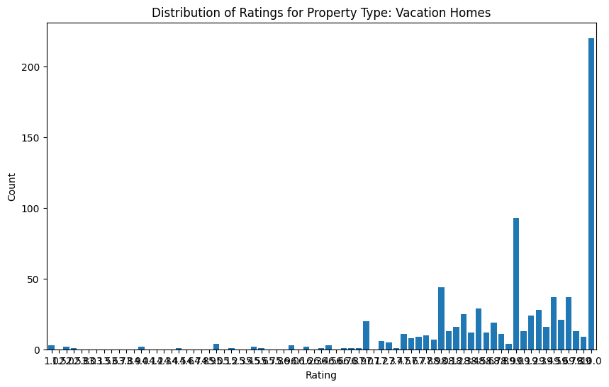

[1 more figures not shown]

```python
# Group ratings by property type
grouped_ratings = df.groupby('atnm')['rating'].value_counts().unstack(fill_value=0)

# Iterate over each property type and create a chart
for prop, ratings in grouped_ratings.iterrows():
    plt.figure(figsize=(10, 6))
    ratings.plot(kind='bar', width=0.8)
    plt.xlabel('Rating')
    plt.ylabel('Count')
    plt.title(f'Distribution of Ratings for Property Type: {prop}')
    plt.xticks(rotation=0)
    plt.show()
```

```python
import folium

# Define a dictionary mapping state names to latitude and longitude coordinates
state_coordinates = {
    'Alabama': (32.806671, -86.791130),
    'Alaska': (61.370716, -152.404419),
    'Arizona': (33.729759, -111.431221),
    'Arkansas': (34.969704, -92.373123),
    'California': (36.116203, -119.681564),
    'Colorado': (39.059811, -105.311104),
    'Connecticut': (41.597782, -72.755371),
    'Delaware': (39.318523, -75.507141),
    'Florida': (27.766279, -81.686783),
    'Georgia': (33.040619, -83.643074),
    'Hawaii': (21.094318, -157.498337),
    'Idaho': (44.240459, -114.478828),
    'Illinois': (40.349457, -88.986137),
    'Indiana': (39.849426, -86.258278),
    'Iowa': (42.011539, -93.210526),
    'Kansas': (38.526600, -96.726486),
    'Kentucky': (37.668140, -84.670067),
    'Louisiana': (31.169546, -91.867805),
    'Maine': (44.693947, -69.381927),
    'Maryland': (39.063946, -76.802101),
    'Massachusetts': (42.230171, -71.530106),
    'Michigan': (43.326618, -84.536095),
    'Minnesota': (45.694454, -93.900192),
    'Mississippi': (32.741646, -89.678696),
    'Missouri': (38.456085, -92.288368),
    'Montana': (46.921925, -110.454353),
    'Nebraska': (41.125370, -98.268082),
    'Nevada': (38.313515, -117.055374),
    'New Hampshire': (43.452492, -71.563896),
    'New Jersey': (40.298904, -74.521011),
    'New Mexico': (34.840515, -106.248482),
    'New York State': (42.165726, -74.948051),
    'North Carolina': (35.630066, -79.806419),
    'North Dakota': (47.528912, -99.784012),
    'Ohio': (40.388783, -82.764915),
    'Oklahoma': (35.565342, -96.928917),
    'Oregon': (44.572021, -122.070938),
    'Pennsylvania': (40.590752, -77.209755),
    'Rhode Island': (41.680893, -71.511780),
    'South Carolina': (33.856892, -80.945007),
    'South Dakota': (44.299782, -99.438828),
    'Tennessee': (35.747845, -86.692345),
    'Texas': (31.054487, -97.563461),
    'Utah': (40.150032, -111.862434),
    'Vermont': (44.045876, -72.710686),
    'Virginia': (37.769337, -78.169968),
    'Washington State': (47.400902, -121.490494),
    'West Virginia': (38.491226, -80.954481),
    'Wisconsin': (44.268543, -89.616508),
    'Wyoming': (42.755966, -107.302490),
}

# Calculate the average rating for all property types together in each state
state_avg_ratings = df.groupby('region_name')['rating'].mean().reset_index()

# Create a map centered on the United States
us_map = folium.Map(location=[37.0902, -95.7129], zoom_start=4)

# Iterate over each state and its average rating
for _, row in state_avg_ratings.iterrows():
    state = row['region_name']  # State name
    avg_rating = row['rating']  # Average rating

    # Get the coordinates for the state
    coordinates = state_coordinates.get(state)

    if coordinates:
        # Create a color gradient based on the average rating
        color = 'red'  # Default color
        if avg_rating >= 8.0:
            color = 'green'
        elif avg_rating >= 7.0:
            color = 'orange'

        # Create a marker for each state and add it to the map
        folium.CircleMarker(
            location=coordinates,
            radius=10,
            color=color,
            fill=True,
            fill_color=color,
            fill_opacity=0.7,
            tooltip=f"{state}<br>Avg Rating: {avg_rating:.2f}",  # Display the state name and average rating as a tooltip
        ).add_to(us_map)

# Display the map
us_map
```

Make this Notebook Trusted to load map: File -> Trust Notebook

[interactive chart not shown]

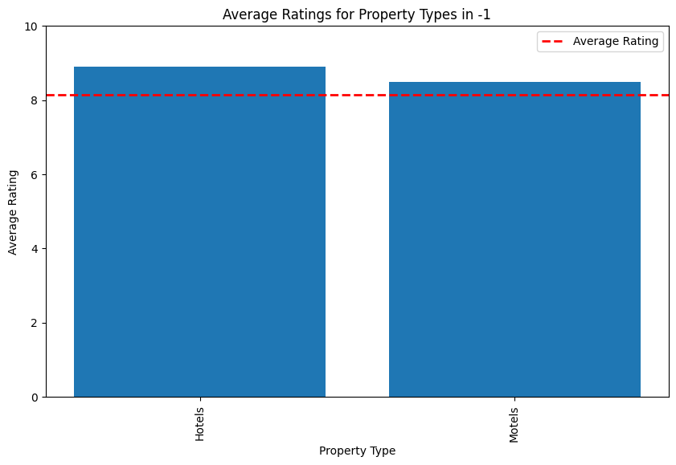

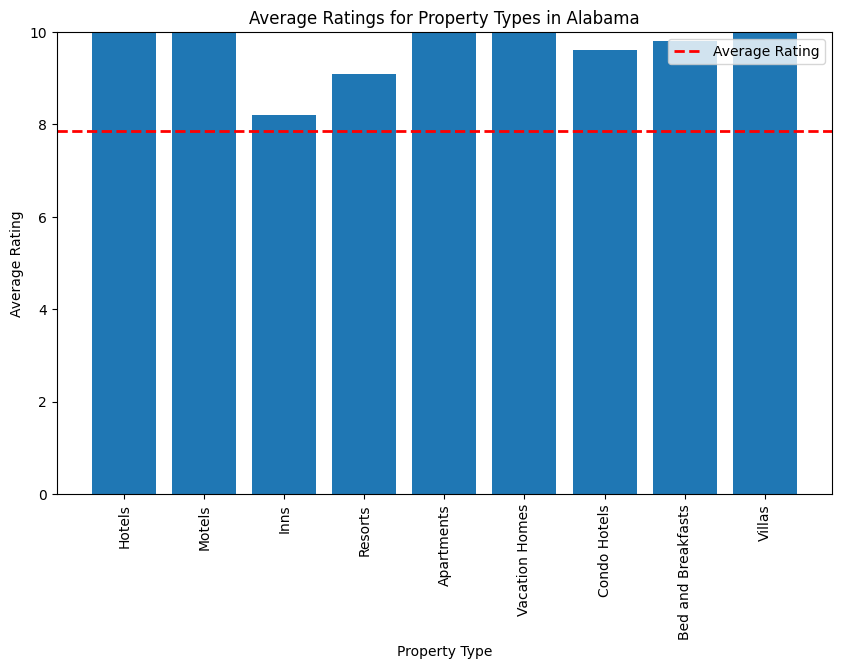

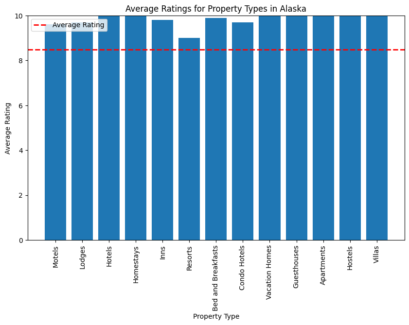

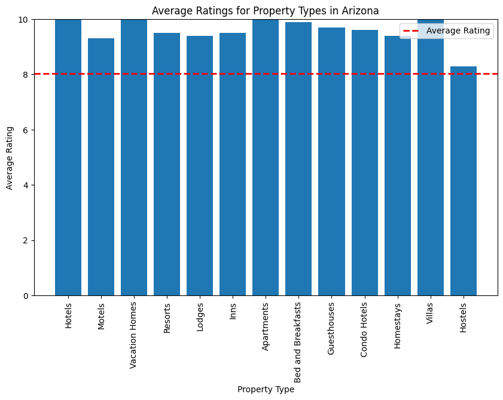

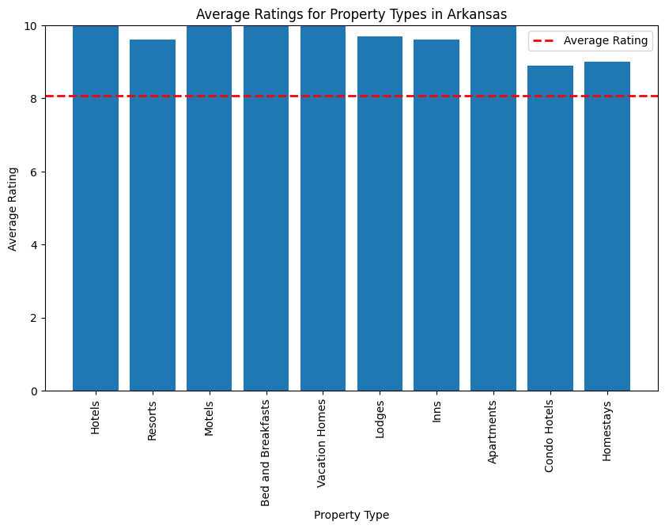

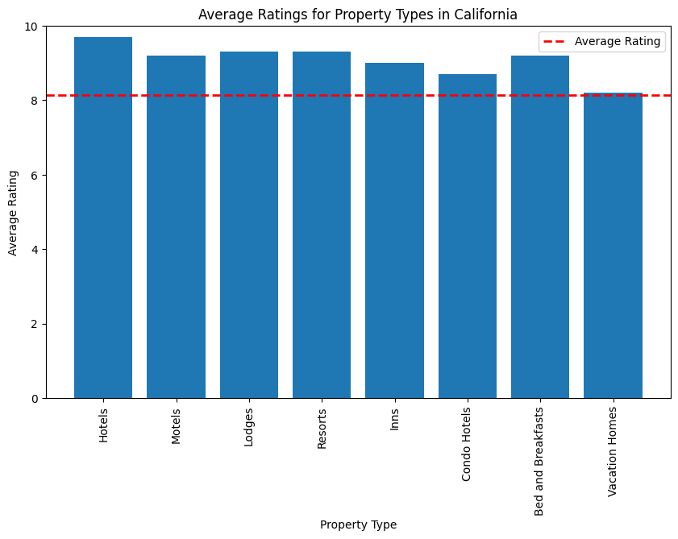

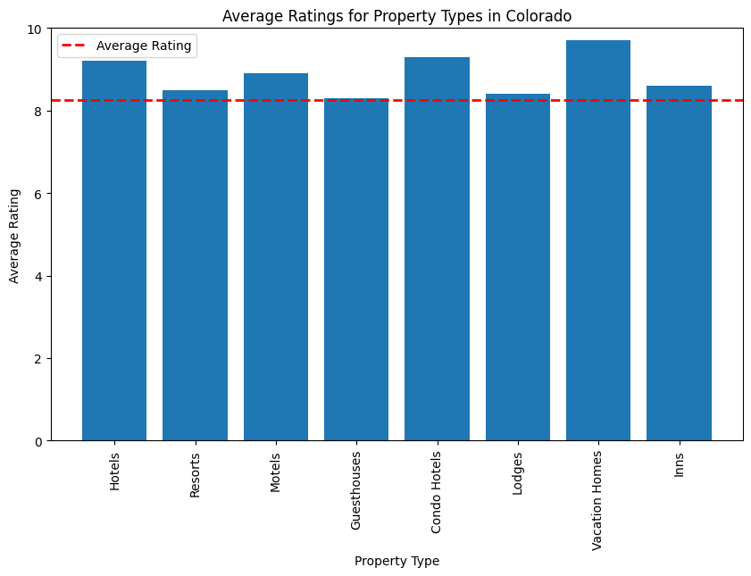

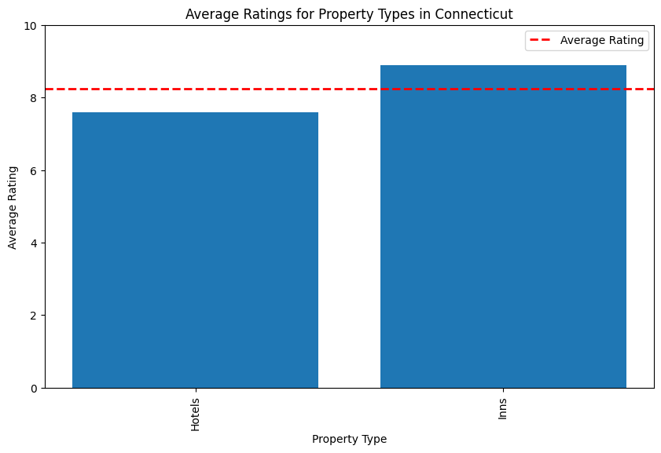

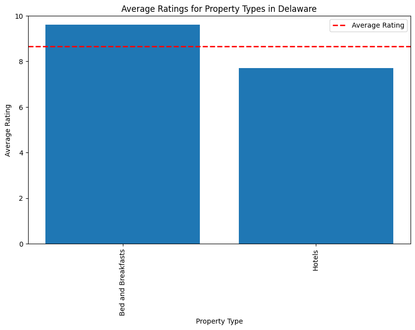

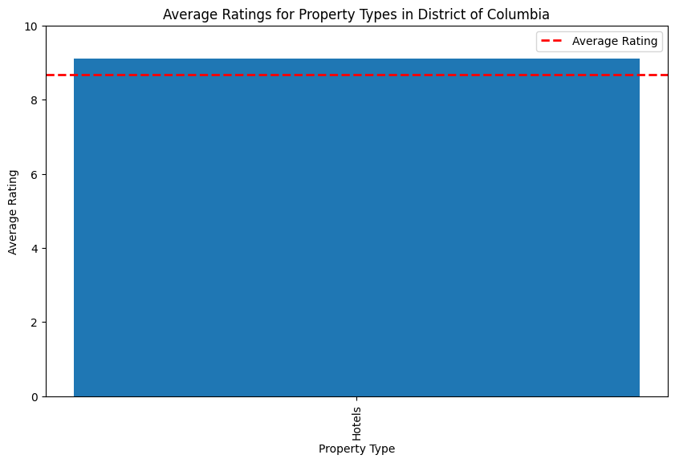

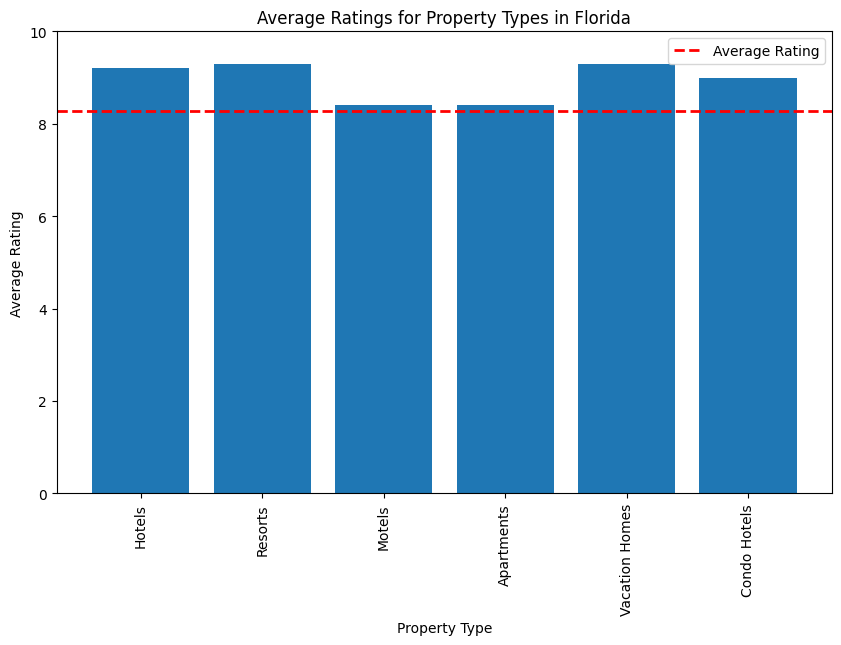

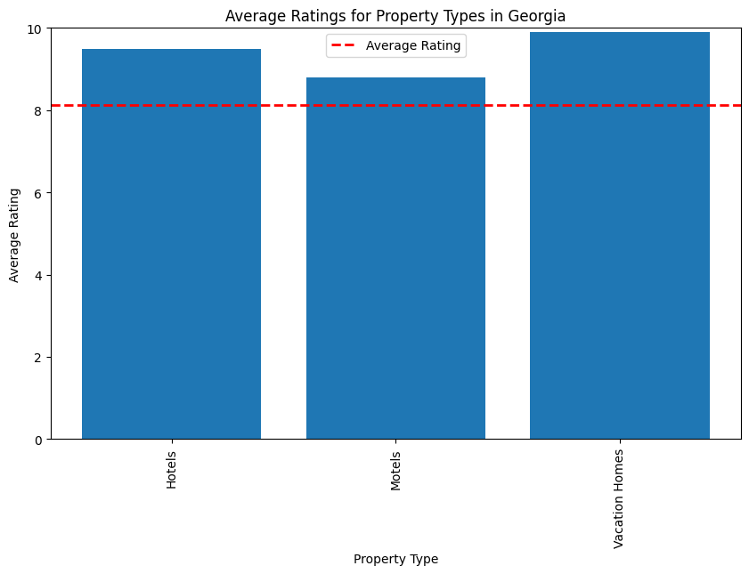

[39 more figures not shown]

```python
import matplotlib.pyplot as plt

# Calculate the average rating for all property types together in each region
region_avg_ratings = df.groupby('region_name')['rating'].mean().reset_index()

# Iterate over each region and create a chart
for _, row in region_avg_ratings.iterrows():
    region = row['region_name']  # Region name
    avg_rating = row['rating']  # Average rating

    # Filter the DataFrame for the current region
    region_data = df[df['region_name'] == region]

    # Create a bar chart for the average rating of all property types in the region
    plt.figure(figsize=(10, 6))
    plt.bar(region_data['atnm'], region_data['rating'])
    plt.xlabel('Property Type')
    plt.ylabel('Average Rating')
    plt.title(f'Average Ratings for Property Types in {region}')
    plt.xticks(rotation=90)
    plt.ylim(0, 10)  # Set the y-axis limits from 0 to 5 (assuming ratings are between 0 and 5)
    plt.axhline(avg_rating, color='red', linestyle='--', linewidth=2, label='Average Rating')
    plt.legend()
    plt.show()
```

# Using the Dataframe's numeric and categorical columns (Linear Regression)

```python
from sklearn.linear_model import LinearRegression
from sklearn.metrics import mean_squared_error

# Select the columns for training
columns = ['atnm', 'region_name', 'outdoor_swimming_pool', 'restaurant', 'free_parking',
           'fitness_center', 'breakfast', 'bar', 'indoor_swimming_pool', 'spa', 'room_service']

# Create the feature matrix X and the target variable y
X = df[columns]
y = df['rating_normalized']

# Perform one-hot encoding on categorical variables
X_encoded = pd.get_dummies(X, columns=['atnm', 'region_name'])

# Split the data into training and testing sets
X_train, X_test, y_train, y_test = train_test_split(X_encoded, y, test_size=0.2, random_state=42)

# Create and train the linear regression model
model = LinearRegression()
model.fit(X_train, y_train)

# Make predictions on the test set
y_pred = model.predict(X_test)

# Calculate the mean squared error
mse = mean_squared_error(y_test, y_pred)

# Print the mean squared error
print("Mean Squared Error:", mse)
```

```
Mean Squared Error: 9.866024842521367e+18
```

# 2. Logistic Regression

```python
sucessful = []
for rating in df.rating:
    if rating > 8:
        sucessful.append(1)
    else : sucessful.append(0)
df["is_successful"] = sucessful
print("Amount of unsuccessful Hotels:")
print(len(df[df.is_successful == 0]))
print("Amount of successful Hotels:")
print(len(df[df.is_successful == 1]))
```

```
Amount of unsuccessful Hotels:
2551
Amount of successful Hotels:
3336
```

```python
df
```

|  | name | rating | atnm | region_name | outdoor_swimming_pool | restaurant | free_parking | fitness_center | breakfast | bar | indoor_swimming_pool | spa | room_service | rating_normalized | is_successful |
| --- | --- | --- | --- | --- | --- | --- | --- | --- | --- | --- | --- | --- | --- | --- | --- |
| 0 | Desert Inn | 7.6 | Motels | New Mexico | 0 | 0 | 0 | 1 | 1 | 0 | 1 | 1 | 0 | 0.349322 | 0 |
| 1 | Super 8 by Wyndham Portales | 6.9 | Motels | New Mexico | 0 | 0 | 1 | 0 | 1 | 0 | 0 | 0 | 0 | 0.165988 | 0 |
| 2 | Ohkay Hotel Casino | 7.9 | Hotels | New Mexico | 1 | 1 | 1 | 1 | 1 | 1 | 0 | 1 | 0 | 0.445397 | 0 |
| 3 | Best Western Plus Portales Inn | 8.6 | Hotels | New Mexico | 0 | 0 | 1 | 1 | 1 | 0 | 0 | 1 | 0 | 0.672089 | 1 |
| 4 | Holiday Inn Express & Suites Portales, an IHG ... | 8.3 | Hotels | New Mexico | 0 | 0 | 0 | 1 | 1 | 0 | 0 | 1 | 0 | 0.577631 | 1 |
| ... | ... | ... | ... | ... | ... | ... | ... | ... | ... | ... | ... | ... | ... | ... | ... |
| 5928 | Motel 6-Porterville, CA | 6.3 | Hotels | California | 1 | 0 | 1 | 0 | 0 | 0 | 0 | 0 | 0 | 0.070802 | 0 |
| 5929 | Wildflower Boutique Motel | 9.4 | Hotels | California | 0 | 0 | 1 | 0 | 1 | 0 | 0 | 0 | 0 | 0.866923 | 1 |
| 5930 | WorldMark Clear Lake | 9.1 | Hotels | California | 0 | 0 | 1 | 0 | 0 | 0 | 0 | 0 | 0 | 0.805686 | 1 |
| 5931 | Sonesta Select Pleasant Hill | 8.0 | Hotels | California | 0 | 1 | 0 | 1 | 1 | 0 | 0 | 1 | 0 | 0.478461 | 0 |
| 5932 | Vineyard Country Inn | 8.8 | Inns | California | 1 | 0 | 1 | 0 | 1 | 0 | 0 | 1 | 0 | 0.729816 | 1 |

5887 rows × 15 columns

```python
#splitting
y = df["is_successful"]
X = df.copy()

X = X.loc[:, X.columns!='name']
X = X.loc[:, X.columns!='rating']
X = X.loc[:, X.columns!='atnm']
X = X.loc[:, X.columns!='region_name']
X = X.loc[:, X.columns!='rating_normalized']
X = X.loc[:, X.columns!='is_successful']

X_train, X_test, y_train, y_test = train_test_split(X, y, test_size = 0.15, random_state = 687)
```

```python
X
```

|  | outdoor_swimming_pool | restaurant | free_parking | fitness_center | breakfast | bar | indoor_swimming_pool | spa | room_service |
| --- | --- | --- | --- | --- | --- | --- | --- | --- | --- |
| 0 | 0 | 0 | 0 | 1 | 1 | 0 | 1 | 1 | 0 |
| 1 | 0 | 0 | 1 | 0 | 1 | 0 | 0 | 0 | 0 |
| 2 | 1 | 1 | 1 | 1 | 1 | 1 | 0 | 1 | 0 |
| 3 | 0 | 0 | 1 | 1 | 1 | 0 | 0 | 1 | 0 |
| 4 | 0 | 0 | 0 | 1 | 1 | 0 | 0 | 1 | 0 |
| ... | ... | ... | ... | ... | ... | ... | ... | ... | ... |
| 5928 | 1 | 0 | 1 | 0 | 0 | 0 | 0 | 0 | 0 |
| 5929 | 0 | 0 | 1 | 0 | 1 | 0 | 0 | 0 | 0 |
| 5930 | 0 | 0 | 1 | 0 | 0 | 0 | 0 | 0 | 0 |
| 5931 | 0 | 1 | 0 | 1 | 1 | 0 | 0 | 1 | 0 |
| 5932 | 1 | 0 | 1 | 0 | 1 | 0 | 0 | 1 | 0 |

5887 rows × 9 columns

```python
y
```

```
0       0
1       0
2       0
3       1
4       1
       ..
5928    0
5929    1
5930    1
5931    0
5932    1
Name: is_successful, Length: 5887, dtype: int64
```

```python
from sklearn.linear_model import LogisticRegression
model = LogisticRegression()
model.fit(X_train, y_train)
y_predicted = model.predict(X_train)
y_predicted
y_train.values
print("Accuracy score for train")

model.score(X_train,y_train)
```

```
Accuracy score for train
```

```
0.6126324205476714
```

```python
y_predicted = model.predict(X_test)
y_predicted
```

```
array([1, 1, 0, 1, 1, 1, 1, 1, 1, 1, 0, 1, 1, 0, 1, 1, 1, 1, 0, 1, 1, 1,
       1, 1, 1, 1, 1, 1, 1, 0, 1, 1, 1, 1, 1, 0, 1, 0, 1, 0, 1, 0, 1, 1,
       1, 1, 0, 1, 1, 1, 1, 1, 1, 1, 1, 1, 1, 1, 1, 1, 1, 1, 0, 1, 1, 1,
       1, 1, 1, 1, 1, 0, 1, 0, 1, 1, 1, 1, 1, 1, 0, 1, 1, 1, 1, 1, 1, 1,
       0, 0, 0, 1, 1, 1, 1, 1, 1, 1, 1, 0, 1, 1, 1, 1, 1, 1, 0, 1, 0, 1,
       1, 1, 0, 1, 1, 0, 0, 0, 1, 0, 0, 0, 1, 0, 1, 1, 1, 1, 1, 0, 0, 1,
       1, 1, 1, 1, 1, 1, 1, 1, 1, 1, 1, 1, 0, 1, 0, 1, 1, 1, 1, 1, 1, 1,
       1, 1, 0, 0, 1, 1, 1, 1, 1, 1, 1, 1, 1, 0, 1, 1, 1, 1, 1, 1, 1, 1,
       1, 1, 0, 0, 0, 1, 1, 1, 1, 1, 1, 0, 0, 1, 1, 1, 1, 1, 1, 1, 1, 1,
       1, 1, 0, 1, 1, 0, 1, 1, 1, 1, 1, 0, 1, 1, 1, 1, 1, 1, 1, 1, 1, 0,
       1, 1, 1, 1, 1, 1, 0, 1, 1, 0, 1, 1, 1, 1, 1, 1, 0, 1, 1, 1, 1, 1,
       1, 1, 0, 0, 1, 1, 1, 1, 1, 1, 1, 1, 1, 1, 1, 0, 1, 1, 1, 1, 1, 1,
       0, 1, 1, 0, 1, 1, 1, 1, 0, 1, 1, 0, 1, 1, 1, 1, 1, 1, 1, 1, 1, 1,
       1, 1, 1, 1, 1, 1, 1, 1, 1, 1, 0, 0, 1, 1, 1, 1, 1, 1, 1, 1, 0, 1,
       1, 1, 1, 1, 1, 1, 0, 1, 1, 0, 1, 1, 1, 1, 1, 0, 1, 1, 1, 1, 0, 1,
```

[output cut: 26 more lines]

```python
y_test.values
```

```
array([1, 0, 1, 1, 1, 0, 1, 0, 1, 1, 1, 1, 0, 1, 1, 1, 1, 1, 1, 0, 1, 0,
       0, 0, 1, 0, 0, 1, 1, 0, 1, 1, 1, 1, 1, 1, 1, 1, 1, 0, 0, 0, 1, 1,
       1, 1, 0, 1, 0, 0, 1, 1, 0, 0, 0, 1, 0, 0, 1, 1, 1, 0, 1, 0, 0, 1,
       0, 0, 0, 1, 1, 0, 1, 1, 1, 0, 0, 0, 1, 1, 1, 1, 1, 1, 0, 0, 1, 1,
       0, 1, 0, 1, 0, 0, 1, 1, 1, 0, 0, 0, 1, 0, 0, 0, 1, 0, 1, 0, 0, 1,
       0, 1, 0, 1, 1, 0, 0, 0, 1, 0, 0, 1, 1, 0, 0, 1, 0, 0, 0, 1, 0, 1,
       1, 1, 0, 1, 1, 0, 1, 1, 1, 0, 1, 1, 0, 0, 1, 1, 0, 1, 1, 1, 1, 0,
       0, 1, 0, 1, 1, 0, 0, 1, 0, 0, 1, 1, 1, 0, 1, 0, 1, 1, 0, 0, 1, 0,
       1, 1, 0, 0, 1, 1, 1, 1, 0, 1, 0, 1, 1, 1, 0, 0, 1, 1, 1, 1, 0, 1,
       0, 1, 0, 0, 1, 0, 1, 1, 1, 1, 0, 0, 0, 1, 0, 1, 1, 1, 1, 1, 0, 0,
       1, 0, 1, 1, 0, 1, 0, 0, 0, 0, 1, 0, 1, 1, 1, 0, 0, 1, 1, 1, 1, 1,
       0, 1, 1, 0, 1, 1, 0, 0, 0, 0, 1, 1, 0, 1, 0, 0, 0, 1, 1, 1, 1, 1,
       1, 1, 0, 0, 1, 0, 1, 1, 0, 1, 1, 0, 1, 0, 1, 1, 0, 1, 1, 0, 1, 1,
       1, 1, 1, 1, 0, 1, 0, 1, 0, 1, 0, 0, 0, 0, 1, 0, 1, 0, 1, 1, 1, 0,
       1, 1, 0, 0, 0, 0, 0, 1, 0, 0, 0, 1, 1, 0, 0, 0, 1, 1, 1, 1, 1, 1,
```

[output cut: 26 more lines]

```python
print("Accuracy score for test")
model.score(X_test,y_test)
```

```
Accuracy score for test
```

```
0.6108597285067874
```

# CONCLUSIONS:

The aim of the research project was to examine whether it is possible to predict the hotel rating based on its parameters.

We approached the problem from various angles and attempted to apply different methods and models in order to achieve accurate prediction results.

We reached the conclusion that regression-based methods, specifically extracting binary parameters from the Booking website, do not provide an efficient solution for our problem.